# Common data distributions for biologists

### 5.8.1 Triangular distribution in R

The triangular distribution is available in the add-on package “triangle” (Carnell 2019). The triangular distribution is accessed using the `_triangle` group of functions, where the space could be `d`, `p`, `q`, or `r`. These functions calculate or returns something different:

- `dtriangle()`: Calculates probability density function (PDF) at *x*.
- `ptriangle()`: Calculates CDF up *a* to *x*. Answers the question, “at what quantile of the distribution should some value fall?”. The reverse of `qtriangle()`.
- `qtriangle()`: Calculates the value at a specified quantile or quantiles. The reverse of `ptriangle()`.
- `rtriangle()`: Draws random numbers from the triangular distribution.

The code below shows the PDFs of various triangular distributions. Notice that `c` is not used as a variable name, to avoid potentially masking the very critical R function `c`.

```r
library(triangle)
```

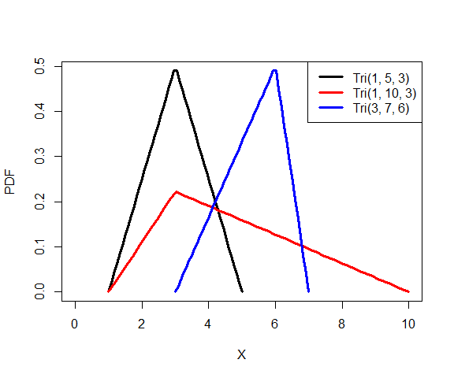

```r
ax <- c(1,1,3)
bx <- c(5, 10, 7)
cx <- c(3, 3, 6)

x1 <- seq(ax[1], bx[1], length=50)
x2 <- seq(ax[2], bx[2], length=50)
x3 <- seq(ax[3], bx[3], length=50)
y1 <- dtriangle(x1, ax[1], bx[1], cx[1])
y2 <- dtriangle(x2, ax[2], bx[2], cx[2])
y3 <- dtriangle(x3, ax[3], bx[3], cx[3])

plot(x1, y1, type="l", lwd=3, xlab="X", ylab="PDF",
     xlim=c(0, 10))
points(x2, y2, type="l", lwd=3, col="red")
points(x3, y3, type="l", lwd=3, col="blue")
legend("topright", legend=c("Tri(1, 5, 3)", "Tri(1, 10, 3)", "Tri(3, 7, 6)"),
       lwd=3, col=c("black", "red", "blue"))
```

The code below demonstrates how a triangular distribution can arise as the distribution of means of two standard uniform variables x1 and x2. The command density estimates the kernel density estimate of a vector. The kernel density estimate is an empirical estimate of the PDF of a variable.

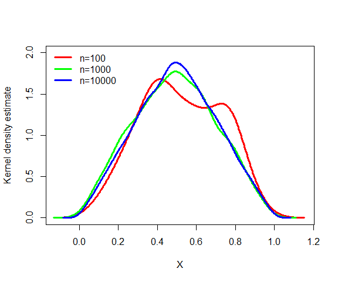

```r
set.seed(42)
n <- 10^(2:4)
x1 <- y <- x <- vector("list", length(n))
for(i in 1:length(n)){
    x[[i]] <- (runif(n[i]) + runif(n[i]))/2
}
for(i in 1:length(n)){
    z <- density(x[[i]])
    x1[[i]] <- z$x
    y[[i]] <- z$y
}

cols <- rainbow(3)
plot(x1[[1]], y[[1]], type="l", lwd=3, col=cols[1],
     xlab="X", ylab="Kernel density estimate", ylim=c(0, 2))
for(i in 2:3){
    points(x1[[i]], y[[i]], type="l", lwd=3, col=cols[i])
}
legend("topleft", legend=c("n=100", "n=1000", "n=10000"),
    bty="n", lwd=3, col=cols[1:3])
```

# 6 Distributions summary

The table below summarizes some the key features of the **discrete distributions** we explored in this module.

| Distribution | Support | What it models |
| --- | --- | --- |
| Bernoulli | 0 or 1 | Outcome of a single binary trial |
| Binomial | [0, *n*] | Number of successes in *n* trials with constant probability *p*. |
| Poisson | [0, +∞] | Number of events occurring independently at constant rate (i.e., count data) |
| Negative binomial | [0, +∞] | Number of failures until a success; or, counts with overdispersion |
| Geometric | [0, +∞] | Number of trials until a single failure with constant probability |
| Beta-binomial | [0, *n*] | Number of successes in *n* trials, with varying *p*. |
| Multinomial | [0, *n*] for each *x<sub>i</sub>*, with sum(*x<sub>i</sub>*) = *n* | Number of counts *x<sub>i</sub>* in *k* categories out of *n* trials. |

The table below summarizes some the key features of the **continuous distributions** we explored in this module.

| Distribution | Support | What it models |
| --- | --- | --- |
| Uniform | [min, max] | Continuous variables where all values are equally likely. |
| Normal | [-∞, +∞] | Many natural processes |
| Lognormal | (0, +∞) | Many processes that are normally distributed on log scale; values arising from multiplicative processes |
| Gamma | (0, +∞] | Waiting times until an event occurs |
| Beta | [0, 1] | Probabilities of single events (i.e., probabilities for binomial processes) |
| Dirichlet | [0, 1] for each *x<sub>i</sub>*, and sum(*x<sub>i</sub>*) = 1 | Probabilities of multiple events (i.e., probabilities for multinomial processes) |
| Exponential | [0, +∞] | Waiting times between events |
| Triangular | [min, max] | Continuous variables about which little is known; requires minimum, maximum, and mode. |

[**Go back to main page**](https://greenquanteco.github.io/index.html)

# 7 References

Carnell, R. 2019. [Triangle: Provides the standard distribution functions for the triangle distribution](https://CRAN.R-project.org/package=triangle).

# 8 Legal notice

This site is for educational purposes only. This work and its content is released under the [Creative Commons Attribution-ShareAlike 4.0](https://creativecommons.org/licenses/by-sa/4.0/) license. Inclusion of third-party data falls under guidelines of fair use as defined in [section 107 of the US Copyright Act of 1976](https://www.law.cornell.edu/uscode/text/17/107).

[^1]: After all, how useful is a dataset with a sample size of 1?
[^2]: If your brain hurts, that’s completely normal. This function gives me headaches too
[^3]: usually greater than the mean
[^4]: It is possible, and not uncommon, to analyze data using the natural log scale but plot results on the log<sub>10</sub> scale. This works because the choice of base is arbitrary for most analyses and because it is simple to convert values between scales with different bases (i.e., change of base).
[^5]: In R, statistics, and in mathematics in general, if you see “log” it usually means “natural log”.